# Enteropathogen antibody dynamics and force of infection among children in low-resource settings

Haiti antibody distributions and seropositivity cutoffs, Figure 1

# Summary

This notebook summarizes the distribution of antibody responses in the Leogane, Haiti cohort.

It fits Gaussian mixture models to the distributions, and where possible, estimates seropositivity cutoffs based on the mixture model fits.

# Script preamble

```r
#-----------------------------
# preamble
#-----------------------------
library(here)
here::here()
```

```
## [1] "/Users/benarnold/enterics-seroepi"
```

```r
# load packages
library(tidyverse)
library(viridis)
library(mixtools)
```

```r
library(knitr)
library(kableExtra)
  options(knitr.table.format = "html")



# set up for parallel computing
# configure for a laptop (use only 3 cores)
library(foreach)
library(doParallel)
registerDoParallel(cores=3)

# bright color blind palette:  https://personal.sron.nl/~pault/
cblack <- "#000004FF"
cblue <- "#3366AA"
cteal <- "#11AA99"
cgreen <- "#66AA55"
cchartr <- "#CCCC55"
cmagent <- "#992288"
cred <- "#EE3333"
corange <- "#EEA722"
cyellow <- "#FFEE33"
cgrey <- "#777777"

# safe color blind palette
# http://jfly.iam.u-tokyo.ac.jp/color/
# http://www.cookbook-r.com/Graphs/Colors_(ggplot2)/
cbPalette <- c("#999999", "#E69F00", "#56B4E9", "#009E73", "#F0E442", "#0072B2", "#D55E00", "#CC79A7")

# viridis color palette
vircols <- viridis(n=7,alpha=1,begin=0.2,end=0.97)
```

#Load the formatted data

```r
#-----------------------------
# load the formatted data
# created with
# haiti-enteric-ab-data-format.Rmd
#-----------------------------
dl <- readRDS(here::here("data","haiti_analysis.rds"))

# list the enteric antigens and formatted labels for them
mbavars <- c("vsp3","vsp5","cp17","cp23","leca","salb","sald","etec","norogi","norogii")

mbalabs <- c("Giardia VSP-3","Giardia VSP-5","Cryptosporidium Cp17","Cryptosporidium Cp23","E. histolytica LecA","Salmonella LPS group B","Salmonella LPS group D","ETEC LT B subunit","Norovirus GI.4", "Norovirus GII.4.NO")
```

#Distribution of antibody levels

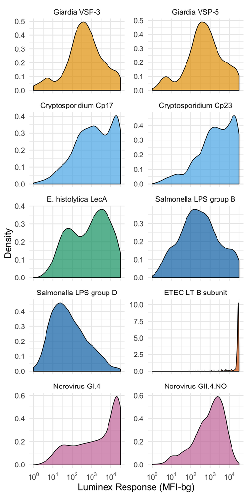

```r
# custom color blind color palette is in the preamble chunck
# pcols <- c(cred,corange,cgreen,cteal,cblue,cmagent)
# pcols <- c(corange,cred,cmagent,cblue,cteal,cgreen)
# pcols <- vircols[c(1:6)]
pcols <- cbPalette[c(2:4,6:8)]


# custom log labels
log10labs <- c(
  expression(10^0),
  expression(10^1),
  expression(10^2),
  expression(10^3),
  expression(10^4)
)

p <- ggplot(data=dl,aes(x=logmfi,group=pathogen,color=pathogen,fill=pathogen)) +
  facet_wrap(~antigenf,nrow=6,ncol=2,scales="free_y") +
  # geom_histogram(aes(y=..density..),bins=50,alpha=0.7) +
  geom_density(aes(y=..density..),color="black",alpha=0.7)+
  scale_x_continuous(limits = c(0,4.5),breaks = 0:4,labels=log10labs) +
  scale_fill_manual(values=pcols) +
  scale_color_manual(values=pcols) +
  labs(x="Luminex Response (MFI-bg)",y="Density") +
  theme_minimal(base_size=16) +
  theme(legend.position = "none")

p
```

#Seropositivity cutoff values

## ROC cutoff values

Add ROC cutoffs from out-of-sample analysis of known positive and negative specimens. Previously published in Moss et al. 2014 AJTMH.

```r
#----------------------------
# Add ROC cutoffs
# Estimated by Jeff Priest
# in Moss et al. 2014 Table 1
#----------------------------
dl$roccut <- NA
dl$roccut[dl$antigen %in% 'leca'] <- log10(302)
dl$roccut[dl$antigen %in% 'cp17'] <- log10(180)
dl$roccut[dl$antigen %in% 'cp23'] <- log10(500)
dl$roccut[dl$antigen %in% 'vsp1'] <- log10(209)
dl$roccut[dl$antigen %in% 'vsp2'] <- log10(270)
dl$roccut[dl$antigen %in% 'vsp3'] <- log10(262)
dl$roccut[dl$antigen %in% 'vsp4'] <- log10(209)
dl$roccut[dl$antigen %in% 'vsp5'] <- log10(206)
```

## Mixture model cutoff estimation

Estimate cutoffs using 2-component Gaussian mixture models, fit with maximum likelihood using the `mixtools` package. Fit the mixture models only using measurements among children $\leq 1$ to ensure a sufficient number of unexposed children and an age range where there are distinct seronegative and seropositive subpopulations (for many enterics, they converge by older ages, as shown below).

```r
#-----------------------------
# mixture models
# fit among children 0-1 years
#-----------------------------
fitmix <- function(x,lambda,k) {
  mixfit <- normalmixEM(x,lambda=lambda,k=k)
  mixcut <- mixfit$mu[order(mixfit$mu)][1]+3*mixfit$sigma[order(mixfit$mu)][1]
  cat(summary(mixfit),"\nCutoff value:",mixcut,"(log10 MFI), or:",
      round(10^mixcut),"(MFI)\n\n")
  # pull out fitted densities
  denmat <- matrix(NA,nrow=length(x),ncol=k)
  denord <- order(mixfit$mu)
  for(i in 1:k) {
    j <- denord[i]
    denmat[,i] <- mixfit$lambda[j] * dnorm(x,mean=mixfit$mu[j],sd=mixfit$sigma[j])
  }
  denmat <- data.frame(denmat)
  colnames(denmat) <- paste("den",1:k,sep="")
  # return original values plus fitted densities in a dataframe
  # also return the cutoff value and normalmixEM object
  xden <- data.frame(x=x,denmat)
  list(xden=xden,mixcut=mixcut,mixfit=mixfit)

}

#-----------------------------
# store densities of mixture distributions
# and estimated cutoffs
# set seed for perfect reproducibility due to
# some unstable estimates in  mixture fits
#-----------------------------
mixdens <- foreach(ab=mbavars,.combine=rbind) %do% {
  cat("\n\n Mixture model fit for ",ab,"\n\n")
  set.seed(2)
  mixf <- fitmix(x=dl$logmfi[dl$antigen==ab & dl$age<=1],lambda=0.5,k=2)
  di <- mixf$xden
  di$mixcut <- mixf$mixcut
  di$antigen=ab
  di <- di %>% arrange(x) %>% select(antigen,mixcut,everything())
  di
}
```

```
##
##
##  Mixture model fit for  vsp3
##
## number of iterations= 35
## summary of normalmixEM object:
##          comp 1   comp 2
## lambda 0.737544 0.262456
## mu     0.534752 2.791084
## sigma  0.369023 0.852003
## loglik at estimate:  -67.68506
##
## Cutoff value: 1.64182 (log10 MFI), or: 44 (MFI)
##
##
##
##  Mixture model fit for  vsp5
##
## number of iterations= 43
## summary of normalmixEM object:
##          comp 1   comp 2
## lambda 0.674696 0.325304
## mu     0.637028 2.558455
## sigma  0.274432 1.049562
## loglik at estimate:  -62.45284
##
## Cutoff value: 1.460324 (log10 MFI), or: 29 (MFI)
##
##
##
##  Mixture model fit for  cp17
##
## number of iterations= 76
## summary of normalmixEM object:
##          comp 1   comp 2
## lambda 0.259076 0.740924
## mu     1.296758 2.346412
## sigma  0.235552 1.237123
## loglik at estimate:  -87.54873
##
```

[output cut: 84 more lines]

```
## Cutoff value: 2.513975 (log10 MFI), or: 327 (MFI)
##
##
##
##  Mixture model fit for  norogii
##
## number of iterations= 40
## summary of normalmixEM object:
##          comp 1   comp 2
## lambda 0.346106 0.653894
## mu     1.126407 2.040643
## sigma  0.304813 1.015192
## loglik at estimate:  -75.64042
##
## Cutoff value: 2.040847 (log10 MFI), or: 110 (MFI)
```

```r
mixcuts <- mixdens %>%
  group_by(antigen) %>% filter(row_number()==1) %>% select(antigen,mixcut) %>% ungroup()

# Distribution for ETEC does not allow for reasonable mixture cutoffs
mixcuts$mixcut[mixcuts$antigen %in% c("etec")] <- NA

#-----------------------------
# merge in the mixture cutoffs
# to the main dataset
#-----------------------------
dl <- left_join(dl,mixcuts,by=c("antigen"))
```

Figure of antibody mixture distributions

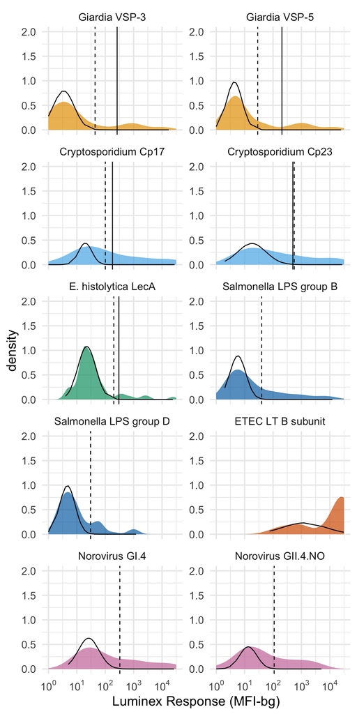

```r
# Get the mixture density distributions
# set the pathogen field to an arbitrary value (Giardia) to
# mesh with the global ggplot aesthetics
plotmixdens <- mixdens %>%
  mutate(antigenf=factor(antigen,levels=mbavars,labels=mbalabs),
         pathogen="Giardia"
         )

# custom color blind color palette (pcols)
# and custom log10 labels (log10labs)
# defined in a previous code chunk
# pcols <- c(cred,corange,cgreen,cteal,cblue,cmagent)
# pcols <- c(corange,cred,cmagent,cblue,cteal,cgreen)
# pcols <- vircols[c(1:6)]
pcols <- cbPalette[c(2:4,6:8)]


pmix <- ggplot(data=filter(dl,age<=1),aes(x=logmfi,group=pathogen,color=pathogen,fill=pathogen)) +
  facet_wrap(~antigenf,nrow=6,ncol=2,scales="free_y") +
  # plot empirical distribution and smooth
  # geom_histogram(aes(y=..density..),bins=50,alpha=0.7) +
  geom_density(aes(y=..density..),color=NA,alpha=0.7)+
  # plot fitted mixture distributions
  geom_line(data=plotmixdens,aes(x=x,y=den1),color=cblack) +
  # geom_line(data=plotmixdens,aes(x=x,y=den2),color=cblack) +
  # add vertical lines for the cutoff values
  geom_vline(aes(xintercept=roccut)) +
  geom_vline(aes(xintercept=mixcut),linetype=2) +
  # labels and formatting
  scale_x_continuous(limits = c(0,4.5),breaks = 0:4,labels=log10labs) +
  coord_cartesian(ylim=c(0,2)) +
  labs(x="Luminex Response (MFI-bg)") +
  scale_fill_manual(values=pcols) +
  scale_color_manual(values=pcols) +
  theme_minimal(base_size = 16) +
  theme(legend.position = "none")

pmix
```

## Cutoffs derived from presumed unexposed

Children under age 2 years whose antibody levels increased by at least 2 on the log10 scale were presumably unexposed at their first measurement. Use them to identify an unexposed distribution.

```r
#-----------------------------
# calculate the change in
# log10 MFI values between
# measurements
#-----------------------------
dl <- dl %>%
  group_by(antigen,id) %>%
  arrange(antigen,id,age) %>%
  mutate(logmfidiff = lead(logmfi) - logmfi) %>%
  mutate(unexp = ifelse(age<=1 & logmfidiff>=2,"Presumed unexposed","Possibly exposed"))

#-----------------------------
# subset the data to
# measurements where the child
# was < 2 years old and the
# change in MFI was >= 2
#-----------------------------
dlunexp <- dl %>%
  filter(unexp=="Presumed unexposed")


#-----------------------------
# calculate the mean and SD
# of each distribution
#-----------------------------
unexp_dists <- dlunexp %>%
  group_by(pathogen,antigen,antigenf) %>%
  summarize(n = n(),
            unexp_mean = mean(logmfi),
            unexp_sd = sd(logmfi),
            unexpcut = unexp_mean + 3*unexp_sd) %>%
  ungroup()
#-----------------------------
# print values
#-----------------------------
knitr::kable(select(unexp_dists,antigenf,n,starts_with("unexp"))) %>%
  kable_styling(bootstrap_options = "striped",full_width = TRUE)
```

| antigenf | n | unexp_mean | unexp_sd | unexpcut |
| --- | --- | --- | --- | --- |
| Giardia VSP-3 | 31 | 0.6147431 | 0.4982120 | 2.109379 |
| Giardia VSP-5 | 29 | 0.6863655 | 0.3975784 | 1.879101 |
| Cryptosporidium Cp17 | 13 | 1.2844600 | 0.4325651 | 2.582155 |
| Cryptosporidium Cp23 | 15 | 1.2525581 | 0.4401907 | 2.573130 |
| E. histolytica LecA | 9 | 1.3050188 | 0.2093717 | 1.933134 |
| Salmonella LPS group B | 12 | 0.7565231 | 0.2053366 | 1.372533 |
| Salmonella LPS group D | 7 | 0.7131032 | 0.5899077 | 2.482826 |
| ETEC LT B subunit | 6 | 2.1681215 | 0.2291517 | 2.855577 |
| Norovirus GI.4 | 7 | 1.4993531 | 0.1953191 | 2.085310 |
| Norovirus GII.4.NO | 12 | 0.8505411 | 0.4645307 | 2.244133 |

```r
#-----------------------------
# merge the cutoff values
# based on presumed unexposed
# back to the main data
#-----------------------------
dlunexp2 <- unexp_dists %>%
  ungroup() %>%
  select(antigen,unexpcut)

dl <- left_join(dl,dlunexp2,by="antigen")
```

## Figure of distributions and cutoffs from presumed unexposed

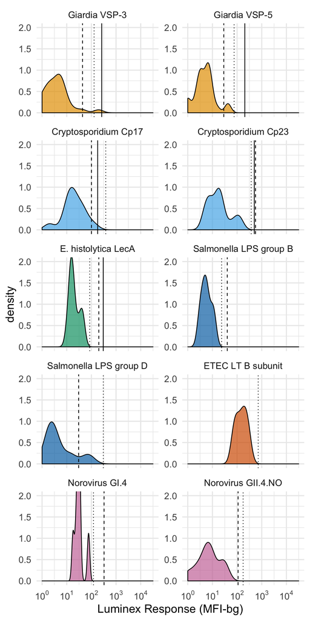

```r
#-----------------------------
# create a figure of the
# unexposed distributions
#-----------------------------
# pcols <- c(cred,corange,cgreen,cteal,cblue,cmagent)
# pcols <- c(corange,cred,cmagent,cblue,cteal,cgreen)
# pcols <- vircols[c(1:6)]
pcols <- cbPalette[c(2:4,6:8)]


punexp <- ggplot(data=filter(dl,unexp=="Presumed unexposed" & !is.na(unexpcut)), aes(x=logmfi,group=pathogen,color=pathogen,fill=pathogen)) +
  facet_wrap(~antigenf,nrow=6,ncol=2,scales="free_y") +
  # plot empirical smoothed distribution
  geom_density(aes(y=..density..),color="black",alpha=0.7)+
  # add vertical lines for the cutoff values
  geom_vline(aes(xintercept=roccut)) +
  geom_vline(aes(xintercept=mixcut),linetype=2) +
  geom_vline(aes(xintercept=unexpcut),linetype=3) +
  # labels and formatting
  scale_x_continuous(limits = c(0,4.5),breaks = 0:4,labels=log10labs) +
  coord_cartesian(ylim=c(0,2)) +
  labs(x="Luminex Response (MFI-bg)") +
  scale_fill_manual(values=pcols) +
  scale_color_manual(values=pcols) +
  theme_minimal(base_size = 16) +
  theme(legend.position = "none")

punexp
```

# Figure1, age-stratified antibody distributions, with cutoffs

**This is Figure 1 in the main text**

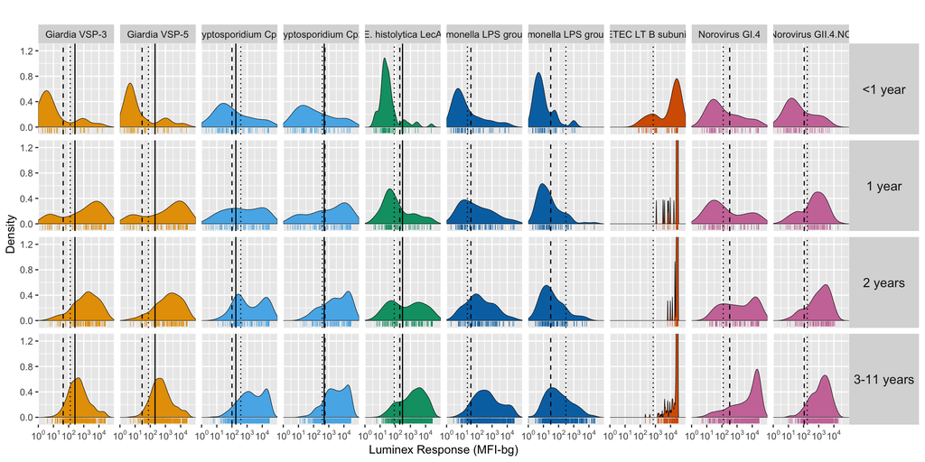

```r
dl <- dl %>%
  mutate(agecat = cut(age,breaks=c(0,1,2,3,12),
                      labels=c("<1 year","1 year","2 years","3-11 years"))
         )

# custom color blind color palette is in the preamble chunck
pcols <- cbPalette[c(2:4,6:8)]

# custom log labels
log10labs <- c(
  expression(10^0),
  expression(10^1),
  expression(10^2),
  expression(10^3),
  expression(10^4)
)

# faceted over age and antigen
p2 <- ggplot(data=dl,aes(x=logmfi,fill=pathogen,color=pathogen)) +
  facet_grid(agecat~antigenf,scales='free')+
  geom_density(aes(y=..density..),color="black",size=0.2,alpha=1)+
  geom_point(aes(y=-0.05),pch="|",alpha=1)+
  geom_vline(aes(xintercept = roccut)) +
  geom_vline(aes(xintercept = mixcut),linetype=2) +
  geom_vline(aes(xintercept = unexpcut),linetype=3) +
  coord_cartesian(ylim=c(-0.05, 1.25))+
  scale_x_continuous(expand=c(0,0),limits=c(0,5),breaks=0:4,labels=log10labs) +
  scale_fill_manual(values=pcols)+
  scale_color_manual(values=pcols)+
  labs(title="",x="Luminex Response (MFI-bg)",y="Density") +
  theme_grey()+
  theme(
    strip.text.x = element_text(size=9),
    strip.text.y=element_text(size=12,angle=0),
    legend.position="none"
  )

p2
```

```r
# save PDF and TIFF versions
ggsave(here::here("figs","Fig1-haiti-ab-distributions-byage.pdf"),plot=p2,device=cairo_pdf,width=16,height=6)
ggsave(here::here("figs","Fig1-haiti-ab-distributions-byage.TIFF"),plot=p2,device="tiff",width=16,height=6)
```

```r
#-----------------------------
# create seropositivity indicators
#-----------------------------
dl <- dl %>%
  mutate(posroc  = ifelse(logmfi > roccut,1,0),
         posmix  = ifelse(logmfi > mixcut,1,0),
         posunex = ifelse(logmfi > unexpcut,1,0))
```

```r
#-----------------------------
# save an updated dataset
# that includes cutoff values
# and seropositive indicators
#-----------------------------
saveRDS(dl,file=here::here("data","haiti_analysis2.rds"))
```